# Antenomeros

Nallely Taiba Pizarro

2026-06-23

#En este archivo vamos a determinar si existen diferencias morfologicas entre machos y hembras, con respecto a su antenomero. Primero, cargamos las librerías:

```r
library(tidyverse)
library(rstatix)
library(ggpubr)
```

#cargamos y preparamos los datos:

```r
data <- read.csv("anten_data.csv", sep = ";", dec = ",")

cols_num <- c("MV1","MV2","MV3","MD1","MD2","MD3","HV1","HV2","HV3","HD1","HD2","HD3")
data[cols_num] <- lapply(data[cols_num], function(x) as.numeric(gsub(",", ".", x)))


data_long <- data %>%
  pivot_longer(cols = all_of(cols_num),
               names_to = "individuo",
               values_to = "valor") %>%
  mutate(
    sexo    = factor(ifelse(grepl("^M", individuo), "Macho", "Hembra")),
    replica = sub("[MH][VD]", "", individuo),
    vista   = ifelse(grepl("V", individuo), "Ventral", "Dorsal")
  )
```

#supuestos estadisticos:

```r
cat("\n=== PRUEBA DE NORMALIDAD (Shapiro-Wilk por Set y Sexo) ===\n")
```

```
##
## === PRUEBA DE NORMALIDAD (Shapiro-Wilk por Set y Sexo) ===
```

```r
shapiro_res <- data_long %>%
  group_by(Set, sexo) %>%
  shapiro_test(valor)
print(shapiro_res)
```

```
## # A tibble: 6 × 5
##   Set    sexo   variable statistic        p
##   <chr>  <fct>  <chr>        <dbl>    <dbl>
## 1 AREA   Hembra valor        0.727 1.80e-12
## 2 AREA   Macho  valor        0.874 8.10e- 8
## 3 LENGTH Hembra valor        0.953 1.10e- 3
## 4 LENGTH Macho  valor        0.897 8.66e- 7
## 5 WIDTH  Hembra valor        0.673 9.68e-14
## 6 WIDTH  Macho  valor        0.965 7.97e- 3
```

```r
cat("\n=== PRUEBA DE HOMOCEDASTICIDAD (Levene por Set) ===\n")
```

```
##
## === PRUEBA DE HOMOCEDASTICIDAD (Levene por Set) ===
```

```r
levene_res <- data_long %>%
  group_by(Set) %>%
  levene_test(valor ~ sexo)
print(levene_res)
```

```
## # A tibble: 3 × 5
##   Set      df1   df2 statistic     p
##   <chr>  <int> <int>     <dbl> <dbl>
## 1 AREA       1   202 0.882     0.349
## 2 LENGTH     1   202 2.33      0.129
## 3 WIDTH      1   202 0.0000949 0.992
```

#todos los valores son p<0,05, por lo que la distribucion de datos no es normal. Lo cual es esperado. Ahora ejecutaremos un test de wilcoxon.

```r
wilcoxon <- data_long %>%
  group_by(Set) %>%
  rstatix::wilcox_test(valor ~ sexo) %>%
  rstatix::adjust_pvalue(method = "BH") %>%
  rstatix::add_significance()
print(wilcoxon)
```

```
## # A tibble: 3 × 10
##   Set    .y.   group1 group2    n1    n2 statistic        p   p.adj p.adj.signif
##   <chr>  <chr> <chr>  <chr>  <int> <int>     <dbl>    <dbl>   <dbl> <chr>
## 1 AREA   valor Hembra Macho    102   102     5770  0.178    1.89e-1 ns
## 2 LENGTH valor Hembra Macho    102   102     6810. 0.000138 4.14e-4 ***
## 3 WIDTH  valor Hembra Macho    102   102     4648. 0.189    1.89e-1 ns
```

#diferencias altamente significativas en el largo de los antenómeros, mas no así en ancho ni área: las hembras tienen antenómeros significativamente mas largos que los machos.

```r
data_long %>%
  filter(Set == "LENGTH") %>%
  group_by(sexo) %>%
  summarise(mediana = median(valor, na.rm=TRUE),
            media   = mean(valor, na.rm=TRUE),
            DE      = sd(valor, na.rm=TRUE))
```

```
## # A tibble: 2 × 4
##   sexo   mediana media    DE
##   <fct>    <dbl> <dbl> <dbl>
## 1 Hembra    370.  362.  96.7
## 2 Macho     341.  323.  81.9
```

```r
data_long %>%
  filter(Set == "LENGTH") %>%
  rstatix::wilcox_effsize(valor ~ sexo)
```

```
## # A tibble: 1 × 7
##   .y.   group1 group2 effsize    n1    n2 magnitude
## * <chr> <chr>  <chr>    <dbl> <int> <int> <ord>
## 1 valor Hembra Macho    0.267   102   102 small
```

#las hembras tienen antenomeros mas largos que los machos, con una mediana de 370,3 um y una media de 361,5 um, mientras que los machos tienen una mediana de 341,1 y una media de 323 um. Sin embargo, estas diferencias son significativas, pero el efecto = 0,267 es bajo.

```r
wilcox_anten <- data_long %>%
  filter(Set == "LENGTH") %>%
  group_by(FL) %>%
  rstatix::wilcox_test(valor ~ sexo) %>%
  rstatix::adjust_pvalue(method = "BH") %>%
  rstatix::add_significance()
print(wilcox_anten, n = Inf)
```

```
## # A tibble: 17 × 10
##    FL      .y.   group1 group2    n1    n2 statistic       p  p.adj p.adj.signif
##    <chr>   <chr> <chr>  <chr>  <int> <int>     <dbl>   <dbl>  <dbl> <chr>
##  1 F10     valor Hembra Macho      6     6        34 0.00866 0.0491 *
##  2 F11     valor Hembra Macho      6     6        28 0.132   0.187  ns
##  3 F12     valor Hembra Macho      6     6        30 0.0649  0.158  ns
##  4 F13     valor Hembra Macho      6     6        36 0.00216 0.0184 *
##  5 F14     valor Hembra Macho      6     6        36 0.00216 0.0184 *
##  6 F15     valor Hembra Macho      6     6        31 0.0411  0.116  ns
##  7 F2      valor Hembra Macho      6     6        24 0.394   0.419  ns
##  8 F3      valor Hembra Macho      6     6        22 0.589   0.589  ns
##  9 F4      valor Hembra Macho      6     6        29 0.0931  0.158  ns
## 10 F5      valor Hembra Macho      6     6        25 0.31    0.351  ns
## 11 F6      valor Hembra Macho      6     6        28 0.132   0.187  ns
## 12 F7      valor Hembra Macho      6     6        27 0.18    0.219  ns
## 13 F8      valor Hembra Macho      6     6        29 0.0931  0.158  ns
## 14 F9      valor Hembra Macho      6     6        31 0.0411  0.116  ns
## 15 Merist… valor Hembra Macho      6     6        29 0.0931  0.158  ns
## 16 Pedicel valor Hembra Macho      6     6        31 0.0411  0.116  ns
## 17 Scalpel valor Hembra Macho      6     6        27 0.18    0.219  ns
```

#F10, F13 y F14 son los responsables de esta diferencia significativa.

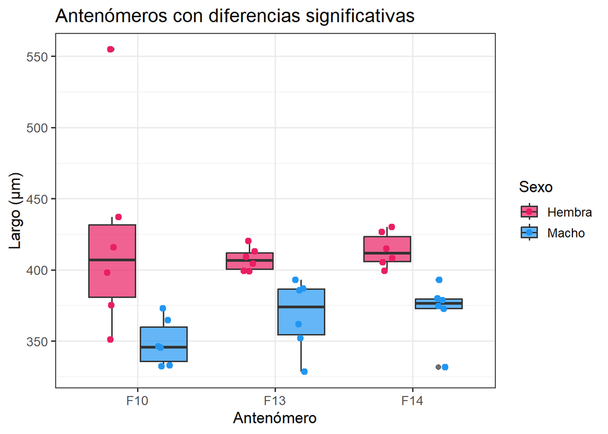

```r
data_long %>%
  filter(Set == "LENGTH", FL %in% c("F10", "F13", "F14")) %>%
  ggplot(aes(x = FL, y = valor, fill = sexo)) +
  geom_boxplot(alpha = 0.7) +
  geom_jitter(aes(color = sexo), position = position_jitterdodge(0.2), size = 2) +
  scale_fill_manual(values = c("Macho" = "#2196F3", "Hembra" = "#E91E63")) +
  scale_color_manual(values = c("Macho" = "#2196F3", "Hembra" = "#E91E63")) +
  labs(title = "Antenómeros con diferencias significativas",
       x = "Antenómero", y = "Largo (µm)", fill = "Sexo", color = "Sexo") +
  theme_bw(base_size = 13)
```

#existe un valor extremo en F10, por lo que evaluaremos que individuo es:

```r
data_long %>%
  filter(Set == "LENGTH", FL == "F10", sexo == "Hembra") %>%
  arrange(desc(valor))
```

```
## # A tibble: 6 × 8
##   FL    SEC   Set    individuo valor sexo   replica vista
##   <chr> <chr> <chr>  <chr>     <dbl> <fct>  <chr>   <chr>
## 1 F10   A12   LENGTH HV2        555. Hembra 2       Ventral
## 2 F10   A12   LENGTH HV3        437. Hembra 3       Ventral
## 3 F10   A12   LENGTH HV1        416. Hembra 1       Ventral
## 4 F10   A12   LENGTH HD1        398. Hembra 1       Dorsal
## 5 F10   A12   LENGTH HD2        375. Hembra 2       Dorsal
## 6 F10   A12   LENGTH HD3        351. Hembra 3       Dorsal
```

#el dato corresponde a HV2, correremos el mismo test sin ese valor para determinar si sigue siendo estadisticamente correcto:

```r
data_long %>%
  filter(Set == "LENGTH", FL == "F10", sexo == "Hembra", individuo != "HV2") %>%
  bind_rows(data_long %>% filter(Set == "LENGTH", FL == "F10", sexo == "Macho")) %>%
  rstatix::wilcox_test(valor ~ sexo)
```

```
## # A tibble: 1 × 7
##   .y.   group1 group2    n1    n2 statistic      p
## * <chr> <chr>  <chr>  <int> <int>     <dbl>  <dbl>
## 1 valor Hembra Macho      5     6        28 0.0173
```

#“Se identificó un valor extremo en HV2 para F10 (555.0 µm); sin embargo, su exclusión no alteró la significancia del resultado (W = 28, p = 0.017), por lo que fue retenido en el análisis.”

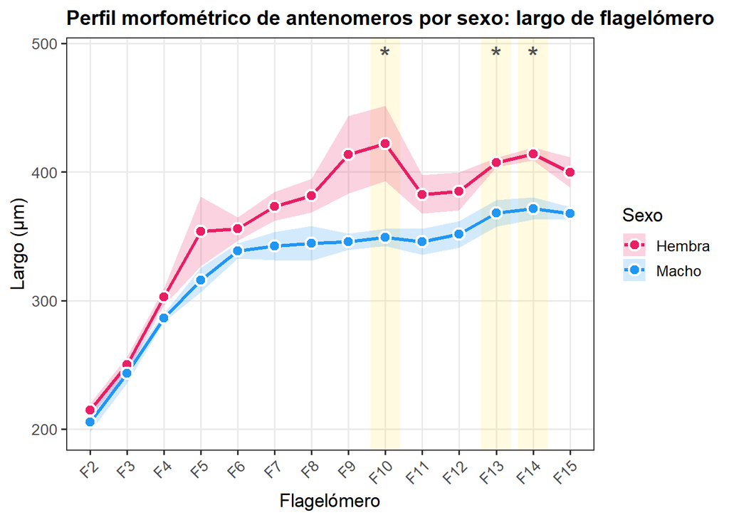

```r
# Perfil completo del flagelo (F2-F15)
perfil <- data_long %>%
  filter(Set == "LENGTH", grepl("^F", FL)) %>%
  mutate(num_ant = as.numeric(sub("F", "", FL))) %>%
  group_by(num_ant, FL, sexo) %>%
  summarise(
    media   = mean(valor, na.rm = TRUE),
    mediana = median(valor, na.rm = TRUE),
    ee      = sd(valor, na.rm = TRUE) / sqrt(n()),
    .groups = "drop"
  )

# Antenómeros significativos para resaltar
sig_ants <- c("F10", "F13", "F14")

p_final <- ggplot(perfil, aes(x = num_ant, y = media, color = sexo, fill = sexo)) +
  # Sombreado de antenómeros significativos
  annotate("rect", xmin = 9.6,  xmax = 10.4, ymin = -Inf, ymax = Inf,
           alpha = 0.12, fill = "gold") +
  annotate("rect", xmin = 12.6, xmax = 13.4, ymin = -Inf, ymax = Inf,
           alpha = 0.12, fill = "gold") +
  annotate("rect", xmin = 13.6, xmax = 14.4, ymin = -Inf, ymax = Inf,
           alpha = 0.12, fill = "gold") +
  # Etiquetas de significancia
  annotate("text", x = 10,  y = 490, label = "*", size = 7, color = "gray30") +
  annotate("text", x = 13,  y = 490, label = "*", size = 7, color = "gray30") +
  annotate("text", x = 14,  y = 490, label = "*", size = 7, color = "gray30") +
  # Banda de error estándar
  geom_ribbon(aes(ymin = media - ee, ymax = media + ee), alpha = 0.2, color = NA) +
  # Línea de perfil
  geom_line(size = 1.1) +
  # Puntos
  geom_point(size = 3, shape = 21, color = "white", stroke = 1.2) +
  # Escalas
  scale_color_manual(values = c("Macho" = "#2196F3", "Hembra" = "#E91E63")) +
  scale_fill_manual(values  = c("Macho" = "#2196F3", "Hembra" = "#E91E63")) +
  scale_x_continuous(breaks = 2:15, labels = paste0("F", 2:15)) +
  # Etiquetas
  labs(
    title    = "Perfil morfométrico de antenomeros por sexo: largo de flagelómero",
        x        = "Flagelómero",
    y        = "Largo (µm)",
    color    = "Sexo",
    fill     = "Sexo"
  ) +
  # Tema
  theme_bw(base_size = 13) +
  theme(
    plot.title      = element_text(face = "bold", size = 14),
    plot.subtitle   = element_text(size = 10, color = "gray40"),
    axis.text.x     = element_text(angle = 45, hjust = 1),
    legend.position = "right",
    panel.grid.minor = element_blank()
  )
print(p_final)
```

```r
ggsave("perfil_flagelo_final.png", p_final, width = 12, height = 6, dpi = 300)
```

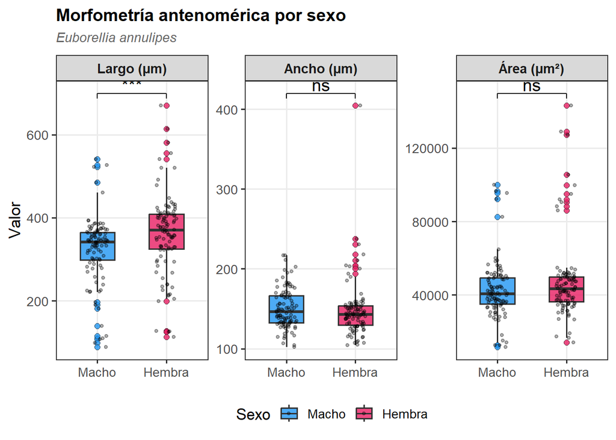

```r
cols_num <- c("MV1","MV2","MV3","MD1","MD2","MD3",
              "HV1","HV2","HV3","HD1","HD2","HD3")

data[cols_num] <- lapply(data[cols_num], function(x) {
  as.numeric(gsub(",", ".", x))
})

data_long <- data %>%
  pivot_longer(
    cols      = all_of(cols_num),
    names_to  = "individuo",
    values_to = "valor"
  ) %>%
  mutate(
    sexo = factor(ifelse(grepl("^M", individuo), "Macho", "Hembra"),
                  levels = c("Macho", "Hembra")),
    vista = ifelse(grepl("V", individuo), "Ventral", "Dorsal")
  )

data_long <- data_long %>%
  mutate(Set_label = case_when(
    Set == "AREA"   ~ "Área (µm²)",
    Set == "LENGTH" ~ "Largo (µm)",
    Set == "WIDTH"  ~ "Ancho (µm)"
  ),
  Set_label = factor(Set_label,
                     levels = c("Largo (µm)", "Ancho (µm)", "Área (µm²)")))

figura1 <- data_long %>%
  filter(!is.na(Set_label)) %>%
  ggplot(aes(x = sexo, y = valor, fill = sexo)) +
  geom_boxplot(outlier.shape = 21, outlier.size = 2,
               alpha = 0.8, width = 0.5) +
  geom_jitter(width = 0.15, alpha = 0.3, size = 1) +
  facet_wrap(~ Set_label, scales = "free_y") +
  stat_compare_means(
    method       = "wilcox.test",
    label        = "p.signif",
    comparisons  = list(c("Macho", "Hembra")),
    bracket.size = 0.5,
    tip.length   = 0.02,
    size         = 5
  ) +
  scale_fill_manual(values = c("Macho" = "#2196F3", "Hembra" = "#E91E63")) +
  labs(
    title    = "Morfometría antenomérica por sexo",
    subtitle = expression(italic("Euborellia annulipes")),
    x        = NULL,
    y        = "Valor",
    fill     = "Sexo"
  ) +
  theme_bw(base_size = 13) +
  theme(
    plot.title      = element_text(face = "bold", size = 14),
    plot.subtitle   = element_text(size = 11, color = "gray40"),
    legend.position = "bottom",
    strip.text      = element_text(face = "bold", size = 11),
    panel.grid.minor = element_blank()
  )

print(figura1)
```

```r
datos_glmm <- data_long %>%
  filter(Set == "LENGTH", grepl("^F", FL)) %>%
  mutate(num_ant = as.numeric(sub("F", "", FL)),
         vista   = factor(vista),
         sexo    = factor(sexo, levels = c("Macho", "Hembra")))

# Modelo 1: solo sexo y posición
m1 <- lm(valor ~ sexo * num_ant, data = datos_glmm)

# Modelo 2: agregando vista
m2 <- lm(valor ~ sexo * num_ant + vista, data = datos_glmm)

# Modelo 3: con interacción sexo x vista
m3 <- lm(valor ~ sexo * num_ant + sexo * vista, data = datos_glmm)

# Comparar modelos
AIC(m1, m2, m3)
```

```
##    df      AIC
## m1  5 1737.334
## m2  6 1729.869
## m3  7 1724.381
```

```r
BIC(m1, m2, m3)
```

```
##    df      BIC
## m1  5 1752.954
## m2  6 1748.613
## m3  7 1746.249
```

```r
summary(m3)
```

```
##
## Call:
## lm(formula = valor ~ sexo * num_ant + sexo * vista, data = datos_glmm)
##
## Residuals:
##     Min      1Q  Median      3Q     Max
## -99.144 -26.361  -0.673  21.929 157.041
##
## Coefficients:
##                         Estimate Std. Error t value Pr(>|t|)
## (Intercept)              240.392     11.089  21.677   <2e-16 ***
## sexoHembra                -3.385     15.683  -0.216   0.8294
## num_ant                   10.024      1.084   9.251   <2e-16 ***
## vistaVentral               2.569      8.736   0.294   0.7690
## sexoHembra:num_ant         2.458      1.532   1.604   0.1106
## sexoHembra:vistaVentral   33.570     12.354   2.717   0.0073 **
## ---
## Signif. codes:  0 '***' 0.001 '**' 0.01 '*' 0.05 '.' 0.1 ' ' 1
##
## Residual standard error: 40.03 on 162 degrees of freedom
## Multiple R-squared:  0.6218, Adjusted R-squared:  0.6101
## F-statistic: 53.26 on 5 and 162 DF,  p-value: < 2.2e-16
```

```r
anova(m3)
```

```
## Analysis of Variance Table
##
## Response: valor
##               Df Sum Sq Mean Sq  F value    Pr(>F)
## sexo           1  49393   49393  30.8222 1.134e-07 ***
## num_ant        1 345692  345692 215.7185 < 2.2e-16 ***
## vista          1  15733   15733   9.8175  0.002052 **
## sexo:num_ant   1   4123    4123   2.5731  0.110641
## sexo:vista     1  11833   11833   7.3839  0.007297 **
## Residuals    162 259607    1603
## ---
## Signif. codes:  0 '***' 0.001 '**' 0.01 '*' 0.05 '.' 0.1 ' ' 1
```

#conclusiones: el test demuestra diferencias significativas en los flagelómeros F10, F13 Y F14 de los antenómeros estudiados. En especifico, esto muestra que el largo de las hembras en esas regiones tienen a ser significativamente mas largos en comparacion con los machos.Por otro lado, la prueba de normalidad indicó que los datos no cumplen con normalidad, esto se podría deber a la cantidad de individuos medidos durante este estudio, sin embargo, los resultados muestra una clara diferencia entre los flagelómeros anteriormente mencionados.